# Telco Customer Churn - Initial Data Exploration

**Business Context:** Analyst report for telecom retention team. Head of Customer Success wants to understand churn drivers, revenue impact, and early warning signs to inform retention strategy.

### 1. Data Foundation

- Dataset Structure & Initial Exploration
- Missing Value Assessment
- Data Type Corrections & Imputation

### 2. Exploratory Data Analysis

- Contract Type & Service Analysis
- Payment Method Patterns
- Tenure & Demographics
- Churn Rate Distributions

### 3. Feature Engineering

- Chi-Square Tests for Categorical Features
- Numerical Feature Correlations
- Business Metrics (Revenue at Risk, Service Count)
- Feature Selection

### 4. Predictive Modeling

- Baseline Logistic Regression
- Class Balancing for Imbalanced Data
- Random Forest Comparison
- Feature Importance & Model Selection

### 5. Behavioral Pattern Analysis

- Churner Profile Development
- Service Adoption vs Churn
- Billing & Payment Risk Combinations
- Monthly Charge Distribution Analysis

### 6. Tenure & Lifecycle Analysis

- Tenure Segmentation (0-12mo vs 13+mo)
- Churn Rate by Lifecycle Stage
- Rolling Churn Rate Trends
- Critical Retention Windows

### 7. Revenue & Business Impact

- Monthly Recurring Revenue (MRR)
- Annual Loss Calculation ($1.67M)
- Revenue at Risk by Contract Type
- Customer Lifetime Value (LTV)

### 8. Risk Segmentation Framework

- 6 Risk Factor Analysis (Contract, Tenure, Value, Payment, Services, Billing)
- Point-Based Scoring System (0-11 points)
- Risk Tier Creation (Critical, High, Moderate, Low)
- Framework Validation & Churn Rate Verification
- High-Risk Customer Export

### 9. SQL Implementation

- Contract Revenue Queries with Aggregations
- Risk Tier Validation with CASE Statements
- Window Functions (RANK OVER) for Prioritization
- Database Export & Validation

### 10. Executive Presentation

- 4 Publication-Ready Charts
- Internal Analyst Report
- Key Findings & Validation Results
- Actionable Recommendations
- Technical Approach & Limitations

|  | customerID | gender | SeniorCitizen | Partner | Dependents | tenure | PhoneService | MultipleLines | InternetService | OnlineSecurity | OnlineBackup | DeviceProtection | TechSupport | StreamingTV | StreamingMovies | Contract | PaperlessBilling | PaymentMethod | MonthlyCharges | TotalCharges | Churn |
| --- | --- | --- | --- | --- | --- | --- | --- | --- | --- | --- | --- | --- | --- | --- | --- | --- | --- | --- | --- | --- | --- |
| 0 | 7590-VHVEG | Female | 0 | Yes | No | 1 | No | No phone service | DSL | No | Yes | No | No | No | No | Month-to-month | Yes | Electronic check | 29.85 | 29.85 | No |
| 1 | 5575-GNVDE | Male | 0 | No | No | 34 | Yes | No | DSL | Yes | No | Yes | No | No | No | One year | No | Mailed check | 56.95 | 1889.5 | No |
| 2 | 3668-QPYBK | Male | 0 | No | No | 2 | Yes | No | DSL | Yes | Yes | No | No | No | No | Month-to-month | Yes | Mailed check | 53.85 | 108.15 | Yes |
| 3 | 7795-CFOCW | Male | 0 | No | No | 45 | No | No phone service | DSL | Yes | No | Yes | Yes | No | No | One year | No | Bank transfer (automatic) | 42.30 | 1840.75 | No |
| 4 | 9237-HQITU | Female | 0 | No | No | 2 | Yes | No | Fiber optic | No | No | No | No | No | No | Month-to-month | Yes | Electronic check | 70.70 | 151.65 | Yes |

```
Shape: (7043, 21)

Data types:
```

```
customerID              str
gender                  str
SeniorCitizen         int64
Partner                 str
Dependents              str
tenure                int64
PhoneService            str
MultipleLines           str
InternetService         str
OnlineSecurity          str
OnlineBackup            str
DeviceProtection        str
TechSupport             str
StreamingTV             str
StreamingMovies         str
Contract                str
PaperlessBilling        str
PaymentMethod           str
MonthlyCharges      float64
TotalCharges            str
Churn                   str
dtype: object
```

```
Index(['customerID', 'gender', 'SeniorCitizen', 'Partner', 'Dependents',
       'tenure', 'PhoneService', 'MultipleLines', 'InternetService',
       'OnlineSecurity', 'OnlineBackup', 'DeviceProtection', 'TechSupport',
       'StreamingTV', 'StreamingMovies', 'Contract', 'PaperlessBilling',
       'PaymentMethod', 'MonthlyCharges', 'TotalCharges', 'Churn'],
      dtype='str')
```

```
Churn
No     5174
Yes    1869
Name: count, dtype: int64
```

```
Churn
No     0.735
Yes    0.265
Name: proportion, dtype: float64
```

|  | SeniorCitizen | tenure | MonthlyCharges |
| --- | --- | --- | --- |
| count | 7043.000000 | 7043.000000 | 7043.000000 |
| mean | 0.162147 | 32.371149 | 64.761692 |
| std | 0.368612 | 24.559481 | 30.090047 |
| min | 0.000000 | 0.000000 | 18.250000 |
| 25% | 0.000000 | 9.000000 | 35.500000 |
| 50% | 0.000000 | 29.000000 | 70.350000 |
| 75% | 0.000000 | 55.000000 | 89.850000 |
| max | 1.000000 | 72.000000 | 118.750000 |

## Initial Analysis Questions

**1. What does one row represent?**  
One customer record with their service details, demographics, and churn status.

**2. What is the churn rate?**  
~26.5% of customers have churned based on value counts above.

**3. Which columns could explain churn behavior?**  
Contract type, tenure, monthly charges, service usage patterns (InternetService, OnlineSecurity, TechSupport), payment method, and senior citizen status appear relevant.

**4. What data is missing that would be useful?**

- Support ticket history (volume, resolution time)
- Customer usage metrics (data consumption, call minutes)
- NPS scores or satisfaction ratings
- Competitor pricing in customer's area
- Length of time before contract renewal

# Data Cleaning & Feature Engineering

## Data Quality

```
array([0, 1])
```

```
['SeniorCitizen', 'tenure', 'MonthlyCharges', 'TotalCharges']
```

```
MonthlyCharges
20.05     0.008661
19.85     0.006389
19.95     0.006247
19.90     0.006247
19.70     0.006105
            ...
72.00     0.000142
108.35    0.000142
63.10     0.000142
44.20     0.000142
78.70     0.000142
Name: proportion, Length: 1585, dtype: float64
```

[figure not shown]

The low extreme has a troublesome peak.

```
Missing: 11 rows (0.16%)
```

|  | tenure | MonthlyCharges | TotalCharges |
| --- | --- | --- | --- |
| 488 | 0 | 52.55 | NaN |
| 753 | 0 | 20.25 | NaN |
| 936 | 0 | 80.85 | NaN |
| 1082 | 0 | 25.75 | NaN |
| 1340 | 0 | 56.05 | NaN |
| 3331 | 0 | 19.85 | NaN |
| 3826 | 0 | 25.35 | NaN |
| 4380 | 0 | 20.00 | NaN |
| 5218 | 0 | 19.70 | NaN |
| 6670 | 0 | 73.35 | NaN |
| 6754 | 0 | 61.90 | NaN |

```
missing_TotalCharges  Churn
False                 No       0.734215
                      Yes      0.265785
True                  No       1.000000
Name: proportion, dtype: float64
```

**Finding:** Missing TotalCharges rows show 0% churn rate. These are new customers (tenure=0) who haven't been charged yet. This will be imputed with 0 to preserve this cohort - they're behaviorally distinct and dropping them would introduce bias.

Based on the Kaggle Dataset details, 'Tenure' is measured in months.

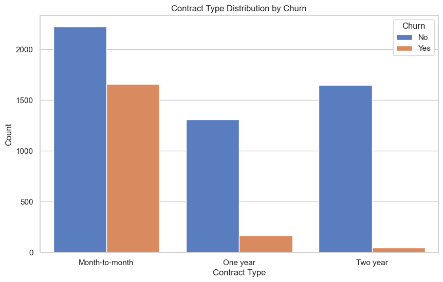

It is clear there is a strong correlation between contract type and turnover which is to be expected.

```
Numerical columns: ['tenure', 'MonthlyCharges', 'TotalCharges']
Categorical columns: ['customerID', 'gender', 'SeniorCitizen', 'Partner', 'Dependents', 'PhoneService', 'MultipleLines', 'InternetService', 'OnlineSecurity', 'OnlineBackup', 'DeviceProtection', 'TechSupport', 'StreamingTV', 'StreamingMovies', 'Contract', 'PaperlessBilling', 'PaymentMethod', 'missing…
```

## Numerical Columns:

- 'tenure'
- 'MonthlyCharges'
- 'TotalCharges'

## Categorical Columns:

- 'customerID'
- 'gender'
- 'SeniorCitizen'
- 'Partner'
- 'Dependents'
- 'PhoneService'
- 'MultipleLines'
- 'InternetService'
- 'OnlineSecurity'
- 'OnlineBackup'
- 'DeviceProtection'
- 'TechSupport'
- 'StreamingTV'
- 'StreamingMovies'
- 'Contract'
- 'PaperlessBilling'
- 'PaymentMethod'
- 'missing_TotalCharges'

## Exploratory Analysis

#### Visualizations of most likely features influencing Churn:

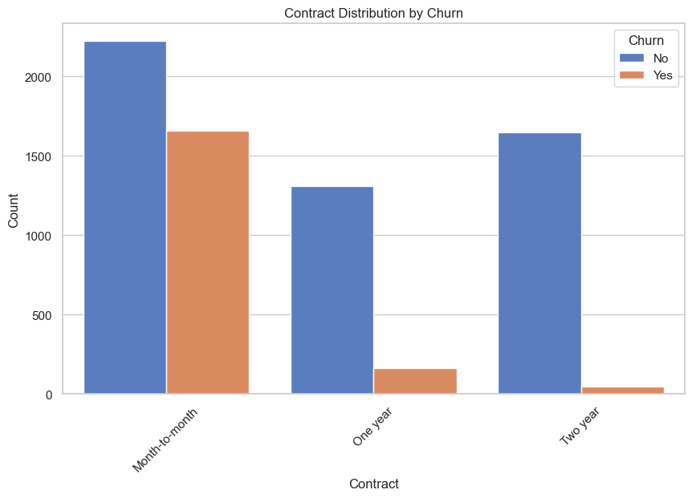

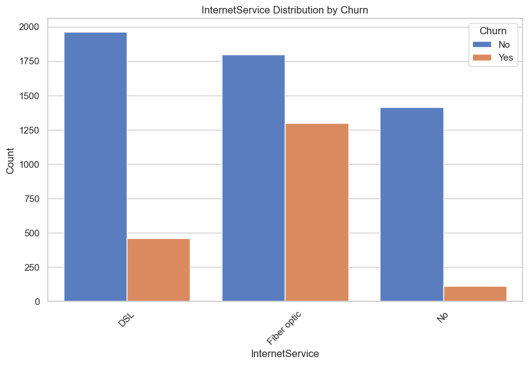

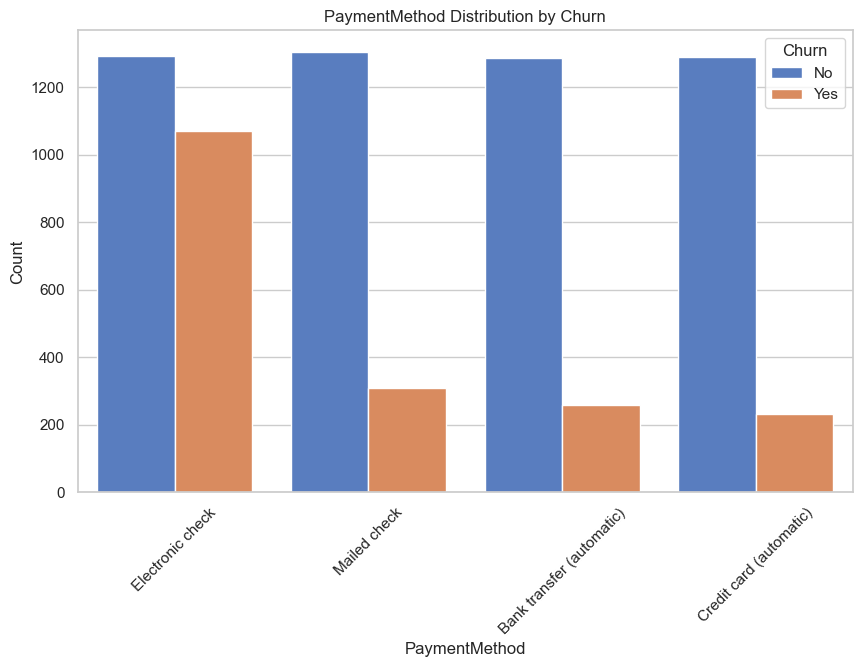

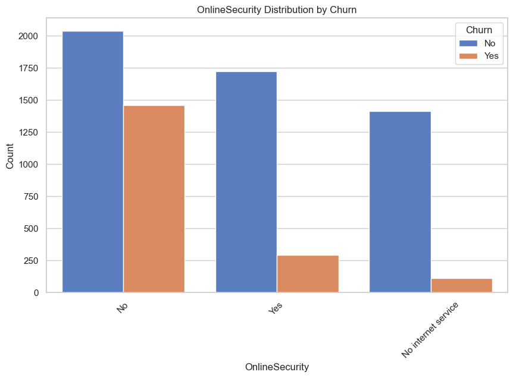

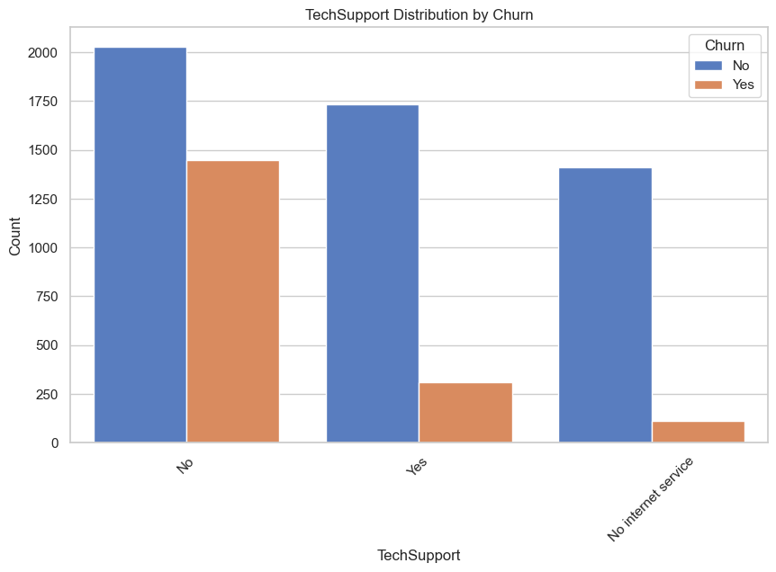

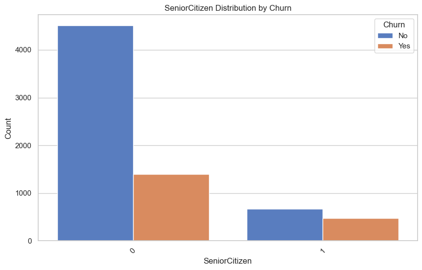

### **Contract Length:**

The negative correlation between contract duration and churn rate is safe to suggest. A cohort analysis

segmenting customers by 2+ year contracts may reveal additional retention patterns, contingent on sufficient

sample size for statistical validity.

### **Internet Service Type:**

Initial hints suggest variation in churn rates across service tiers (Fiber, DSL, No service). Further

segmentation analysis is warranted to assess whether modern infrastructure adoption correlates with

different customer retention profiles compared to legacy technology like DSL or Landline. This could

indicate technology satisfaction or demographic factors requiring deeper investigation.

### **Payment Method:**

indicators. Modern payment adoption could serve as a proxy for digital literacy or customer lifecycle stage,

potentially identifying higher-risk retention segments.

### **Online Security:**

Customers with OnlineSecurity services appear to exhibit lower churn rates compared to those without. Value-added

security features may signal deeper customer engagement with the service ecosystem, suggesting product bundling

strategies could strengthen retention. The relationship between security service adoption and churn warrants

quantitative validation to determine if this represents genuine causation or correlates with other factors such as

contract type or customer tenure.

### **Tech Support:**

Observable patterns suggest TechSupport availability correlates with reduced churn probability. This aligns with

established customer service literature linking support accessibility to satisfaction metrics. The absence of tech

support among churned customers may indicate unresolved service issues or perceived lack of value. Investigation

into support utilization rates (actual usage vs. availability) could reveal whether retention benefits stem from

active support engagement or simply the reassurance of available assistance.

### **Senior Citizen Status:**

Demographic segmentation by age reveals potential variation in churn behavior between senior and non-senior

customer cohorts. This pattern may reflect differences in product needs, price sensitivity, or service

expectations across age segments. Further analysis should examine whether seniors demonstrate distinct contract

preferences or service adoption patterns that could inform targeted retention campaigns or age-appropriate product

offerings tailored to this demographic segment.

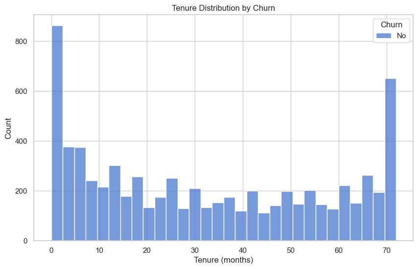

The tenure distribution appears to exhibit bimodal characteristics, with customer concentrations at both extremes—new subscribers and long-tenured accounts. This pattern is commonly observed in churn analysis and may indicate distinct customer segments requiring different retention strategies.

```
Tenure Stats:
count    7043.000000
mean       32.371149
std        24.559481
min         0.000000
25%         9.000000
50%        29.000000
75%        55.000000
max        72.000000
Name: tenure, dtype: float64

By Churn:
        count       mean        std  min   25%   50%   75%   max
Churn
No     5174.0  37.569965  24.113777  0.0  15.0  38.0  61.0  72.0
Yes    1869.0  17.979133  19.531123  1.0   2.0  10.0  29.0  72.0

Lifecycle Distribution:
0-12m: 31.0%
13-24m: 14.5%
25-36m: 11.8%
37+m: 42.6%
```

Tenure Periods:

- 0-12 months: First year customers
- 13-24 months: Year 2, first renewal window
- 25-36 months: Established customers
- 37+ months: Long-term loyalty segment

## **Tenure Analysis:**

#### **Key Findings:**

- Long-tenure customers exhibit significantly lower churn rates, suggesting higher customer lifetime value (LTV)
- Early-stage customers (0-12 months) demonstrate elevated churn risk, consistent with industry patterns
- The inverse relationship between tenure and churn indicates retention improves over time

#### **Business Implications:**

- Higher CAC investment may be justified for customer segments with proven retention longevity
- Long-term contract incentives appear to drive sustained customer relationships

#### **Further Investigation:**

- Contract type distribution across tenure cohorts (month-to-month vs annual subscribers)
- Revenue optimization: monthly MRR accumulation vs yearly contract value
- ROI comparison: acquisition cost of longer contracts vs extended retention of monthly subscribers

## Feature Engineering

### Categorical Feature Selection

```
gender: Chi2=0.48, p-value= 0.4866
SeniorCitizen: Chi2=159.43, p-value= 0.0000
Partner: Chi2=158.73, p-value= 0.0000
Dependents: Chi2=189.13, p-value= 0.0000
PhoneService: Chi2=0.92, p-value= 0.3388
MultipleLines: Chi2=11.33, p-value= 0.0035
InternetService: Chi2=732.31, p-value= 0.0000
OnlineSecurity: Chi2=850.00, p-value= 0.0000
OnlineBackup: Chi2=601.81, p-value= 0.0000
DeviceProtection: Chi2=558.42, p-value= 0.0000
TechSupport: Chi2=828.20, p-value= 0.0000
StreamingTV: Chi2=374.20, p-value= 0.0000
StreamingMovies: Chi2=375.66, p-value= 0.0000
Contract: Chi2=1184.60, p-value= 0.0000
PaperlessBilling: Chi2=258.28, p-value= 0.0000
PaymentMethod: Chi2=648.14, p-value= 0.0000
```

Strong categorical predictors:

Very Strong (Chi² > 500):

1. Contract (Chi²=1184.60)
2. OnlineSecurity (Chi²=850.00)
3. TechSupport (Chi²=828.20)
4. InternetService (Chi²=732.31)
5. PaymentMethod (Chi²=648.14)
6. OnlineBackup (Chi²=601.81)
7. DeviceProtection (Chi²=558.42)

Strong (Chi² > 150):

8. StreamingTV (Chi²=374.20)
9. StreamingMovies (Chi²=375.66)
10. PaperlessBilling (Chi²=258.28)
11. Dependents (Chi²=189.13)
12. SeniorCitizen (Chi²=159.43)
13. Partner (Chi²=158.73)

Weak but Significant:

- MultipleLines (Chi²=11.33, p=0.0035)

Safe to Drop (Not Statistically Significant):

- gender (Chi²=0.48, p=0.4866)
- PhoneService (Chi²=0.92, p=0.3388)
- customerID
- missing_TotalCharges

### Numerical Feature Correlation Analysis

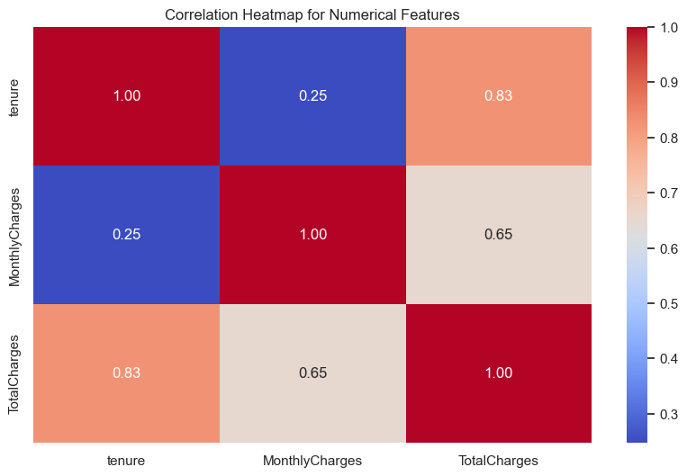

|  | feature_1 | feature_2 | abs_corr |
| --- | --- | --- | --- |
| 2 | tenure | TotalCharges | 0.826178 |
| 6 | TotalCharges | tenure | 0.826178 |
| 5 | MonthlyCharges | TotalCharges | 0.651174 |
| 7 | TotalCharges | MonthlyCharges | 0.651174 |
| 1 | tenure | MonthlyCharges | 0.247900 |
| 3 | MonthlyCharges | tenure | 0.247900 |

## Predictive Modeling - Baseline Pipeline

|  | tenure | MonthlyCharges | TotalCharges | Contract_Month-to-month | Contract_One year | InternetService_DSL | InternetService_No | PaymentMethod_Bank transfer (automatic) | PaymentMethod_Credit card (automatic) | PaymentMethod_Electronic check |
| --- | --- | --- | --- | --- | --- | --- | --- | --- | --- | --- |
| 0 | 0.102371 | -0.521976 | -0.262257 | 1.0 | 0.0 | 1.0 | 0.0 | 0.0 | 0.0 | 1.0 |
| 1 | -0.711743 | 0.337478 | -0.503635 | 1.0 | 0.0 | 0.0 | 0.0 | 0.0 | 0.0 | 0.0 |
| 2 | -0.793155 | -0.809013 | -0.749883 | 0.0 | 0.0 | 1.0 | 0.0 | 0.0 | 0.0 | 0.0 |
| 3 | -0.263980 | 0.284384 | -0.172722 | 0.0 | 0.0 | 1.0 | 0.0 | 0.0 | 1.0 | 0.0 |
| 4 | -1.281624 | -0.676279 | -0.989374 | 1.0 | 0.0 | 1.0 | 0.0 | 0.0 | 0.0 | 1.0 |

```
Classification Report:
              precision    recall  f1-score   support

          No       0.84      0.89      0.86      1035
         Yes       0.64      0.53      0.58       374

    accuracy                           0.79      1409
   macro avg       0.74      0.71      0.72      1409
weighted avg       0.79      0.79      0.79      1409
```

### First Model Performance Summary

**Accuracy: 79%** - Decent , but the breakdown reveals problems.

**Non-Churners:**

- Precision: 84%, Recall: 89%, F1: 86%
- The model handles these well. Most customers who stay are correctly identified.

**For Churners:**

- Precision: 64%, Recall: 53%, F1: 58%
- This is the problem. We only catch 53% of customers who actually churn.

**What this means:** Out of 374 customers who churned in the test set, we missed identifying about 176 of them. That's basically half of all churners with a missed oppertunity for retention.

**The issue:** The model prefers to predict customers that will stay rather than leave. This minimizes false alarms but costs big in customer attrition. It is better to have the false alarms than leaving retention oppertunities on the table.

**Imbalance impact:** The dataset has roughly 3x more non-churners than churners (1035 vs 374). The model learned to favor the majority class, which inflates overall accuracy.

**Approach:** Adjusting the threshold or applying class balancing in efforts to catch churners is better than the cost of a wasted retention offer.

## Improving Recall - Class Balancing

|  | Approach | Precision | Recall | F1 |
| --- | --- | --- | --- | --- |
| 0 | Lower Threshold | 0.55 | 0.74 | 0.63 |
| 1 | Class Weights | 0.50 | 0.80 | 0.62 |

**Class balancing wins.** Catches 80% of churners vs 74% with threshold adjustment. Precision drops slightly (50% vs 55%), but for retention strategy, it's better to contact more customers than miss actual churners.

## Final Model - Performance & Insights

**Hypothesis:** Class weighting improves recall by penalizing misclassified churners during training, forcing the model to prioritize minority class detection over overall accuracy.

```
              precision    recall  f1-score   support

          No       0.91      0.71      0.80      1035
         Yes       0.50      0.80      0.62       374

    accuracy                           0.74      1409
   macro avg       0.71      0.76      0.71      1409
weighted avg       0.80      0.74      0.75      1409
```

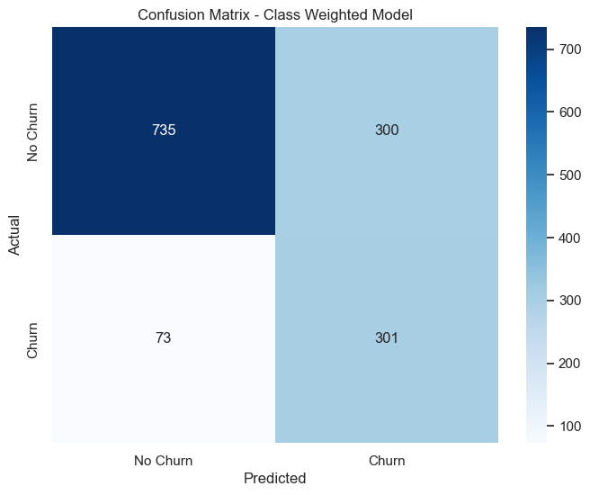

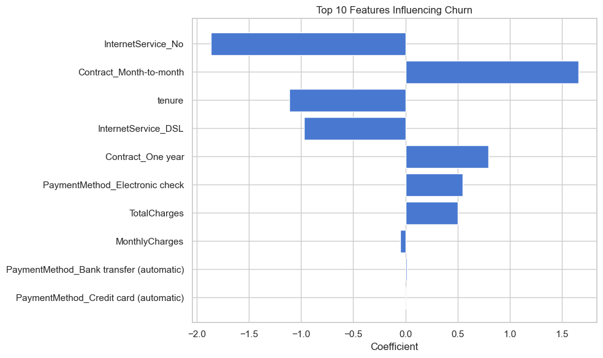

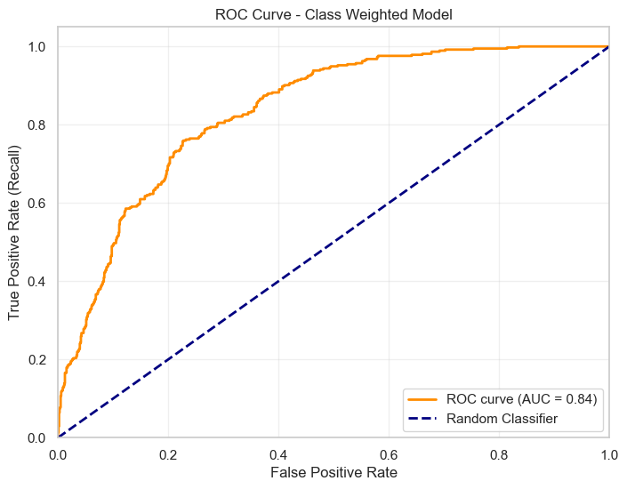

## Random Forest Comparison

|  | Model | Recall | AUC |
| --- | --- | --- | --- |
| 0 | Logistic Regression | 0.80 | 0.84 |
| 1 | Random Forest | 0.48 | 0.80 |

## Service Engagement Model

**Hypothesis:** Service adoption (TechSupport, OnlineSecurity, etc.) signals deeper customer engagement and may reduce churn beyond just contract type.

| Service_Count | Churn_Rate | Customers |
| --- | --- | --- |
| 0 | 0.21 | 2219 |
| 1 | 0.46 | 966 |
| 2 | 0.36 | 1033 |
| 3 | 0.27 | 1118 |
| 4 | 0.22 | 852 |
| 5 | 0.12 | 571 |
| 6 | 0.05 | 284 |

|  | Model | Recall | AUC |
| --- | --- | --- | --- |
| 0 | Combined (Contract + Services) | 0.80 | 0.84 |

|  | Model | Recall | AUC |
| --- | --- | --- | --- |
| 0 | Contract Model (6 features) | 0.80 | 0.84 |
| 1 | Random Forest | 0.48 | 0.80 |
| 2 | Combined Model (13 features) | 0.80 | 0.84 |

## Services-Only Model

**Hypothesis:** Service features alone can predict churn independent of contract type, testing whether add-on adoption is a standalone retention signal or merely correlated with contractual commitment.

|  | Model | Recall | AUC |
| --- | --- | --- | --- |
| 0 | Services Only (7 features) | 0.77 | 0.76 |

|  | Model | Recall | AUC |
| --- | --- | --- | --- |
| 0 | Contract Model (6 features) | 0.80 | 0.84 |
| 1 | Random Forest | 0.48 | 0.80 |
| 2 | Combined Model (13 features) | 0.80 | 0.84 |
| 3 | Services Only (7 features) | 0.77 | 0.76 |

**Business Recommendation:** Deploy contract based model for churn prediction. Target month to month customers with 0 to 2 services for retention campaigns offering TechSupport or OnlineSecurity bundles. Service adoption won't replace contract conversion but provides behavioral segmentation within high risk contract tiers.

## Additional Feature Engineering

**Purpose:** Business analysis features for revenue impact calculations and value density metrics. These features enable strategic retention targeting and financial forecasting beyond predictive modeling.

### Revenue at Risk

**Rationale:** Quantifies monthly revenue exposure from churned customers. Translates churn probability into financial impact for executive reporting and ROI calculations on retention initiatives.

| Contract | Revenue_At_Risk | MonthlyCharges | Pct_At_Risk |
| --- | --- | --- | --- |
| Month-to-month | 120847.0 | 257294.0 | 47.0 |
| One year | 14118.0 | 95817.0 | 14.7 |
| Two year | 4165.0 | 103006.0 | 4.0 |

### Revenue Per Service

**Rationale:** Value density metric measuring revenue efficiency across service adoption levels. Identifies high value customers with low service engagement—prime upsell candidates who reduce churn risk through increased product stickiness.

| Service_Count | Revenue_Per_Service | MonthlyCharges | Churn_Rate |
| --- | --- | --- | --- |
| 0 | 32.79 | 32.79 | 0.21 |
| 1 | 65.57 | 65.57 | 0.46 |
| 2 | 36.21 | 72.42 | 0.36 |
| 3 | 26.70 | 80.11 | 0.27 |
| 4 | 21.94 | 87.77 | 0.22 |
| 5 | 18.44 | 92.18 | 0.12 |
| 6 | 16.56 | 99.37 | 0.05 |

### Feature Engineering Summary

|  | customerID | tenure | Service_Count | MonthlyCharges | Revenue_Per_Service | Revenue_At_Risk | Churn |
| --- | --- | --- | --- | --- | --- | --- | --- |
| 0 | 7590-VHVEG | 1 | 1 | 29.85 | 29.850000 | 0.00 | No |
| 1 | 5575-GNVDE | 34 | 2 | 56.95 | 28.475000 | 0.00 | No |
| 2 | 3668-QPYBK | 2 | 2 | 53.85 | 26.925000 | 53.85 | Yes |
| 3 | 7795-CFOCW | 45 | 3 | 42.30 | 14.100000 | 0.00 | No |
| 4 | 9237-HQITU | 2 | 0 | 70.70 | 70.700000 | 70.70 | Yes |
| 5 | 9305-CDSKC | 8 | 3 | 99.65 | 33.216667 | 99.65 | Yes |
| 6 | 1452-KIOVK | 22 | 2 | 89.10 | 44.550000 | 0.00 | No |
| 7 | 6713-OKOMC | 10 | 1 | 29.75 | 29.750000 | 0.00 | No |
| 8 | 7892-POOKP | 28 | 4 | 104.80 | 26.200000 | 104.80 | Yes |
| 9 | 6388-TABGU | 62 | 2 | 56.15 | 28.075000 | 0.00 | No |

**Engineered features complete.** Three business analysis features created: Service_Count (engagement depth), Revenue_At_Risk (financial exposure), Revenue_Per_Service (value density). Dataset ready for revenue impact analysis, cohort behavioral profiling, and risk tier segmentation.

## Behavioral Patterns - What Do Churners Look Like?

Building profiles of a churned customer. Comparing numerical stats and finding high-churn combinations in categorical features.

### Churner vs Retained - Numerical Comparison

|  | Retained | Churned | Difference_% |
| --- | --- | --- | --- |
| MonthlyCharges | 61.27 | 74.44 | 21.5 |
| tenure | 37.57 | 17.98 | -52.1 |
| TotalCharges | 2549.91 | 1531.80 | -39.9 |
| Service_Count | 2.14 | 1.77 | -17.3 |
| Revenue_Per_Service | 29.36 | 45.70 | 55.7 |

### High-Churn Combinations - Billing & Payment

| PaperlessBilling | PaymentMethod | Customers | Churn_Rate |
| --- | --- | --- | --- |
| Yes | Electronic check | 1742 | 0.498 |
| No | Electronic check | 623 | 0.327 |
| Yes | Mailed check | 656 | 0.273 |
|  | Bank transfer (automatic) | 891 | 0.209 |
|  | Credit card (automatic) | 882 | 0.190 |
| No | Mailed check | 956 | 0.135 |
|  | Bank transfer (automatic) | 653 | 0.110 |
|  | Credit card (automatic) | 640 | 0.100 |

### Service Adoption vs Churn

| Service_Count | Customers | Churn_Rate | Avg_Monthly |
| --- | --- | --- | --- |
| 0 | 2219 | 0.214 | 32.793 |
| 1 | 966 | 0.458 | 65.574 |
| 2 | 1033 | 0.358 | 72.417 |
| 3 | 1118 | 0.274 | 80.111 |
| 4 | 852 | 0.223 | 87.772 |
| 5 | 571 | 0.124 | 92.176 |
| 6 | 284 | 0.053 | 99.365 |

### Monthly Charges Distribution - Churned vs Retained

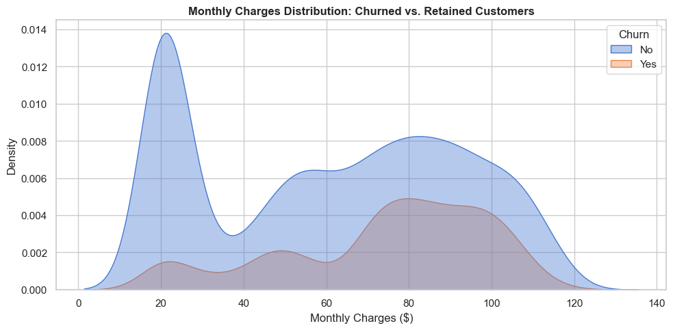

## CHURNER PROFILE

**Average churned customer:**

**Contract & payment patterns:**

- Heavily skewed to month-to-month contracts
- Electronic check payers show highest churn rates especially with paperless billing
- Paperless billing + electronic check combo is the riskiest segment

**Service engagement:**

- Lower service adoption correlates with higher churn
- Customers with 0-2 services have significantly higher churn than those with 4+ services
- Less likely to have TechSupport or OnlineSecurity

**What this means:** Churners are paying more per month but haven't been around long enough to accumulate much total value. They're less engaged with the service ecosystem (fewer add-ons) which means less switching cost. The month-to-month contract combined with low service adoption creates a low-friction exit path.

**Key insight:** It's not just about price - it's about value perception. Higher monthly charges with fewer services means customers feel like they're overpaying. The retention play is either bundle more services at the current price point or convert them to annual contracts where the commitment psychology kicks in.

## Tenure Cohort Analysis - When Do Customers Leave?

Finding the point in the customer lifecycle where churn is highest. Need to when to intervene with retention efforts.

### Create Tenure Bands

Segment customers by lifecycle stage to understand when churn risk peaks.

```
Tenure_Band
0-3 months      1062
4-12 months     1124
13-24 months    1024
25-48 months    1594
49-72 months    2239
Name: count, dtype: int64
```

### Churn Rate by Tenure Band

| Tenure_Band | Customers | Churned | Churn_Rate | Avg_Monthly | Avg_Services |
| --- | --- | --- | --- | --- | --- |
| 0-3 months | 1062 | 597 | 0.562 | 53.316 | 0.729 |
| 4-12 months | 1124 | 440 | 0.391 | 58.726 | 1.278 |
| 13-24 months | 1024 | 294 | 0.287 | 61.357 | 1.589 |
| 25-48 months | 1594 | 325 | 0.204 | 65.931 | 2.171 |
| 49-72 months | 2239 | 213 | 0.095 | 73.945 | 3.151 |

### Monthly Churn Rate - Survival View

Calculate churn rate at each tenure month with a rolling average to smooth the pattern.

|  | tenure | Total_At_Tenure | Churned_At_Tenure | Churn_Rate_At_Tenure | Churn_Rate_Rolling |
| --- | --- | --- | --- | --- | --- |
| 0 | 0 | 11 | 0 | 0.000000 | NaN |
| 1 | 1 | 613 | 380 | 0.619902 | 0.378903 |
| 2 | 2 | 238 | 123 | 0.516807 | 0.535570 |
| 3 | 3 | 200 | 94 | 0.470000 | 0.486133 |
| 4 | 4 | 176 | 83 | 0.471591 | 0.474265 |
| 5 | 5 | 133 | 64 | 0.481203 | 0.438810 |
| 6 | 6 | 110 | 40 | 0.363636 | 0.411384 |
| 7 | 7 | 131 | 51 | 0.389313 | 0.364804 |
| 8 | 8 | 123 | 42 | 0.341463 | 0.372444 |
| 9 | 9 | 119 | 46 | 0.386555 | 0.371983 |

### Lifecycle Churn Visualization

Two views: churn rate by tenure bands (left) and rolling churn rate across all months (right).

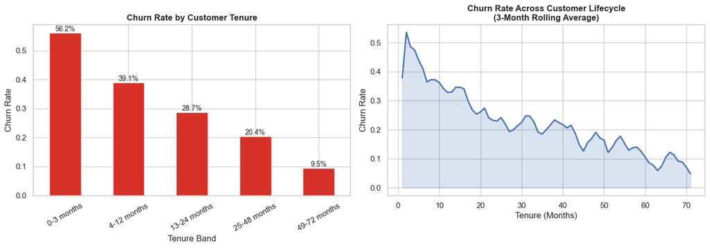

## LIFECYCLE INSIGHT

**Churn concentration:** The 0-3 month cohort shows highest churn risk. New customers who just signed up are most likely to leave before they get invested in the service. This is a classic onboarding problem. It could pay off to look into getting customers to 'aha' moments quicker. Maybe that could look like a successful first tech support experience, streaming quality they notice, or bundled service value they actually use.

**The numbers:**

- 0-3 months: Highest churn rate among all tenure bands
- 4-12 months: Churn rate remains elevated but starts declining
- 13-24 months: Churn drops significantly once customers pass the 1-year mark
- 25+ months: Established customers show lowest churn - they're locked in

**What this means:** The business has an early-stage retention problem. Customers who make it past 12 months tend to stick around. The issue is getting them there in the first place. There's a strong chance that this is more so a customer experience issue than anything else.

**The intervention window:** Months 0-12 are probably the most important. I'd be willing to wager that this is where retention campaigns matter the most. We can see that after 12 months, turn drops quite a bit. The rolling average shows churn risk meets the extreme earlier on and steadily declines as tenure goes up.

**Potential Retention strategy:**

- Focus on first 90 days: onboarding quality, early value demonstration, quick wins
- Target 4-12 month customers with engagement campaigns before they hit renewal decisions
- Don't waste retention budget on 25+ month customers - they're already sticky
- Convert month-to-month to annual contracts during the 3-6 month window when they've seen value but aren't committed yet

## Revenue Impact Visualization

**Purpose:** Translate churn predictions into financial impact for budget allocation and retention ROI calculations.

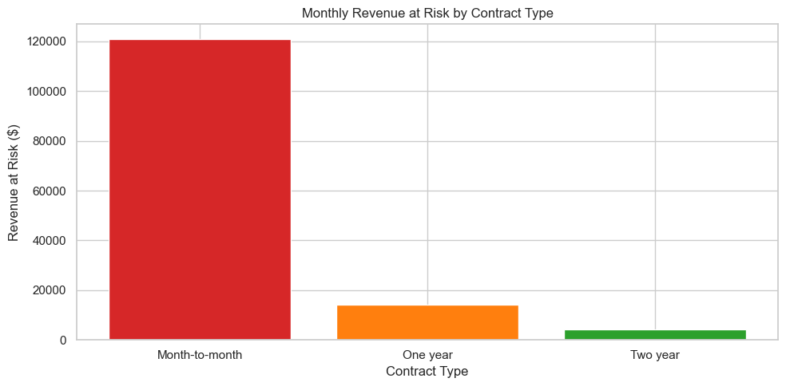

| Contract | Revenue_At_Risk | MonthlyCharges | Risk_Pct |
| --- | --- | --- | --- |
| Month-to-month | 120847.0 | 257294.0 | 47.0 |
| One year | 14118.0 | 95817.0 | 15.0 |
| Two year | 4165.0 | 103006.0 | 4.0 |

### Revenue Impact Quantification

**Purpose:** Quantify total financial exposure from churn across customer base for executive budget allocation.

|  | Metric | Value |
| --- | --- | --- |
| 0 | Total MRR | $456,117 |
| 1 | Churned MRR | $139,131 |
| 2 | Annual Loss | $1,669,570 |
| 3 | Estimated Avg LTV | $2,096 |

## REVENUE IMPACT STATEMENT

The average customer lifetime value is estimated at **$2,096**, calculated as average monthly charge multiplied by average tenure. With 1,869 customers churning, the total lifetime value at risk is approximately $3.9M.

**Budget Allocation Recommendation:** Prioritize retention spending on month to month customers in their first 12 months. This segment combines highest churn probability with recoverable revenue potential.

## Risk Segmentation Framework

Rule based customer risk scoring system for retention team targeting. A translation of analytical insights into actionable customer prioritization using logic, not machine learning.

**Methodology:**

This framework applies a rule-based scoring system to identify high-risk customers based on six validated churn predictors. Each customer receives a risk score (0-11 points) determined by their characteristics across contract terms, tenure, service engagement, and payment behavior.

**Framework Components:**

1. **Risk Factor Analysis** - Quantify churn rate differentials for each predictor
2. **Point-Based Scoring** - Weight factors by relative impact (1-3 points each)
3. **Risk Tier Segmentation** - Group customers into actionable retention categories
4. **Framework Validation** - Verify tier separation and predictive accuracy
5. **Business Application** - Revenue impact analysis and retention targeting

**Approach:** Logic-based segmentation enables interpretable, actionable retention strategies without machine learning complexity.

### Risk Factor 1: Contract Type

**Hypothesis:** Month-to-month contracts exhibit higher churn rates due to reduced switching costs and lower commitment barriers.

**Rationale:** Contract type demonstrates the strongest differentiation in churn behavior across all evaluated factors. Customers without long-term commitment periods face minimal friction when considering competitive alternatives, making this our highest-weighted risk factor.

**Weight Assignment:** 3 points (strongest predictor)

| Contract | Churn_Rate_% | Churned_Customers | Total_Customers | Relative_to_One_Year | Relative_to_Two_Year |
| --- | --- | --- | --- | --- | --- |
| Month-to-month | 42.7 | 1655 | 3875 | 3.8 | 15.3 |
| One year | 11.3 | 166 | 1473 | 1.0 | 4.0 |
| Two year | 2.8 | 48 | 1695 | 0.2 | 1.0 |

### Risk Factor 2: Customer Tenure

**Hypothesis:** First-year customers demonstrate elevated churn risk during the onboarding and value-discovery phase.

**Rationale:** Early-stage customers (0-12 months) exhibit significantly higher churn rates compared to established accounts. This pattern reflects the critical onboarding window before customer commitment solidifies and switching costs accumulate through service adoption and familiarity.

**Weight Assignment:** 2 points (strong predictor, second tier)

| Tenure_Segment | Churn_Rate_% | Churned_Customers | Total_Customers | Relative_Risk |
| --- | --- | --- | --- | --- |
| 0-12 months | 47.4 | 1037 | 2186 | 2.8 |
| 13+ months | 17.1 | 832 | 4857 | 1.0 |

### Risk Factor 3: Value Perception

**Hypothesis:** High-cost customers with minimal service adoption exhibit value misalignment, increasing churn propensity.

**Rationale:** Customers paying premium rates (>$65/month) while utilizing fewer than 2 services represent poor value perception. This pricing-to-engagement imbalance creates dissatisfaction and heightens competitive switching motivation, as customers perceive inadequate return on their monthly investment.

**Weight Assignment:** 2 points (behavioral signal of value misalignment)

| Value_Segment | Churn_Rate_% | Churned_Customers | Total_Customers | Relative_Risk |
| --- | --- | --- | --- | --- |
| High Cost Low Value | 57.8 | 549 | 950 | 2.7 |
| Other | 21.7 | 1320 | 6093 | 1.0 |

### Risk Factor 4: Payment Method

**Hypothesis:** Electronic check users demonstrate lower commitment levels and higher churn propensity.

**Rationale:** Electronic check payment correlates with elevated churn rates, potentially signaling lower digital engagement, weaker banking integration, or reduced commitment compared to credit card or automated payment users. This payment method may serve as a proxy for customer lifecycle stage or financial stability.

**Weight Assignment:** 1 point (tertiary predictor)

| Payment_Segment | Churn_Rate_% | Churned_Customers | Total_Customers | Relative_Risk |
| --- | --- | --- | --- | --- |
| Electronic check | 45.3 | 1071 | 2365 | 2.6 |
| Other | 17.1 | 798 | 4678 | 1.0 |

### Risk Factor 5: Service Engagement

**Hypothesis:** Customers without protective services demonstrate lower product engagement and ecosystem investment.

**Rationale:** Absence of both TechSupport and OnlineSecurity indicates minimal service adoption beyond baseline connectivity. These customers lack deep product engagement and perceived value-add features, reducing switching costs and making competitive migration more attractive.

| Service_Engagement | Churn_Rate_% | Churned_Customers | Total_Customers | Relative_Risk |
| --- | --- | --- | --- | --- |
| Low Engagement | 49.0 | 1250 | 2553 | 3.6 |
| Other | 13.8 | 619 | 4490 | 1.0 |

### Risk Factor 6: Paperless Billing

**Hypothesis:** Paperless billing adoption correlates with reduced engagement touchpoints and higher churn propensity.

**Rationale:** Paperless billing users demonstrate elevated churn rates compared to paper billing customers. Physical billing statements create regular touchpoints and may indicate more traditional, committed customer segments. Digital-only communication reduces engagement frequency and brand visibility.

**Weight Assignment:** 1 point (tertiary predictor)

| Paperless_Segment | Churn_Rate_% | Churned_Customers | Total_Customers | Relative_Risk |
| --- | --- | --- | --- | --- |
| Other | 16.3 | 469 | 2872 | 1.0 |
| Paperless billing | 33.6 | 1400 | 4171 | 2.1 |

## Risk Scoring Logic

Based on the six factors analyzed above, I'll assign point values that reflect each factor's impact on churn. Looking at the relative risk ratios from the analyses:

**Point Assignment (ordered by relative risk):**

- **3 points** → Month-to-month contract (15.3x relative risk - clearly the strongest predictor)
- **2 points** → No tech/security services (3.6x relative risk - second strongest factor)
- **2 points** → Tenure ≤12 months (2.8x relative risk)
- **2 points** → High charges + few services (2.7x relative risk - value perception issue)
- **1 point** → Electronic check payment (2.6x relative risk)
- **1 point** → Paperless billing (2.1x relative risk - weakest signal)

Total possible score: 11 points. Higher scores = higher churn risk. This weighting directly reflects the magnitude of each factor's impact on churn probability.

|  | Risk Factor | Churn_Rate_% | Relative_Risk | Points_Assigned |
| --- | --- | --- | --- | --- |
| 0 | Month-to-month contract | 42.7 | 15.3 | 3 |
| 1 | No tech/security services | 49.0 | 3.6 | 2 |
| 2 | Tenure ≤12 months | 47.4 | 2.8 | 2 |
| 3 | High charges + few services | 57.8 | 2.7 | 2 |
| 4 | Electronic check payment | 45.3 | 2.6 | 1 |
| 5 | Paperless billing | 33.6 | 2.1 | 1 |

## Build Risk Scoring Function

Based on the six risk factors analyzed above, I'll create a function to calculate each customer's risk score (0-11 points).

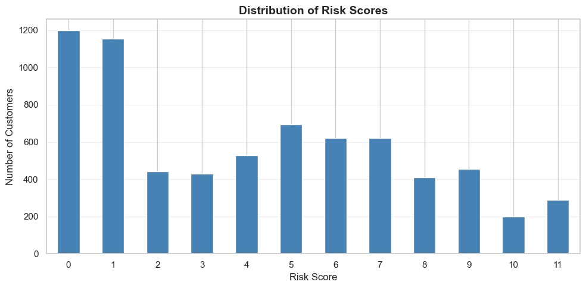

```
count    7043.000000
mean        4.194093
std         3.362204
min         0.000000
25%         1.000000
50%         4.000000
75%         7.000000
max        11.000000
Name: Risk_Score, dtype: float64
```

## Calculate Risk Scores

Applying the scoring function to all customers:

| Risk_Tier | Customer_Count | Percentage |
| --- | --- | --- |
| Low Risk | 2797 | 39.7 |
| Moderate Risk | 1648 | 23.4 |
| High Risk | 1243 | 17.6 |
| Critical Risk | 1355 | 19.2 |

## Create Risk Tiers

Grouping scores into 4 actionable tiers:

- **Low Risk** (0-2): Stable customers
- **Moderate Risk** (3-5): Some warning signs
- **High Risk** (6-7): Multiple risk factors
- **Critical Risk** (8-11): Urgent intervention needed

| Risk_Tier | Total_Customers | Churned_Customers | Churn_Rate_% | Pct_of_Customers | MRR_At_Risk |
| --- | --- | --- | --- | --- | --- |
| Low Risk | 2797 | 152 | 5.4 | 39.7 | 13174.25 |
| Moderate Risk | 1648 | 356 | 21.6 | 23.4 | 25288.95 |
| High Risk | 1243 | 509 | 40.9 | 17.6 | 38234.20 |
| Critical Risk | 1355 | 852 | 62.9 | 19.2 | 62433.45 |

## Validate Framework

Checking if churn rate actually increases with risk tier:

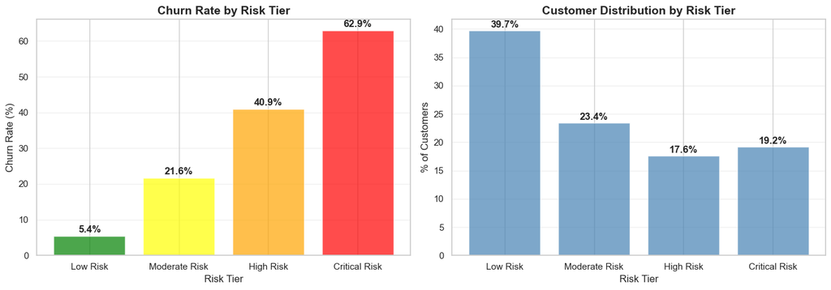

```
Risk_Tier
Critical Risk    1355
High Risk        1243
Low Risk            0
Moderate Risk       0
Name: count, dtype: int64
```

## Export High-Risk Customers

Creating a CSV file for the retention team with High and Critical risk customers:

## Summary and Next Steps

### What I Learned

1. Month-to-month contracts (biggest factor)
2. Short tenure (under 12 months)
3. High charges with few services
4. Electronic check payment
5. No support services
6. Paperless billing

The validation shows this works - churn rates increase steadily from Low Risk to Critical Risk tiers.

### Recommendations for Retention Team

**Priority 1: Critical Risk Customers**

- These customers have the highest churn likelihood
- Focus on month-to-month customers in their first year
- Consider proactive outreach with contract upgrade incentives

**Priority 2: High Risk Customers**

- Multiple risk factors present
- Look at value perception - are high-paying customers getting enough services?
- May benefit from service bundles or discounts

**Priority 3: Moderate Risk**

- Monitor for changes in status
- Standard retention communications should be sufficient

**Priority 4: Low Risk**

- Stable customer base
- Focus on upselling opportunities rather than retention

### What Could Be Improved

- Could test different point weights to see if that improves separation
- Might want to look at customer lifetime value to prioritize high-value accounts
- Would be interesting to track how scores change over time

The main advantage of this scoring system is that it's transparent for stakeholders, which should make a path to implementation of retention strategies.

## SQL Validation

To demonstrate these findings using SQL, I'll recreate some key analyses using SQLite. This could be useful if the data were in a production database and stakeholders wanted to run their own queries.

```
7043
```

### Query 1: Churn Rate and Revenue Impact by Contract Type

First, I'll look at how contract types impact both churn rates and revenue. This is basically recreating the contract analysis from earlier but using SQL instead of pandas.

|  | Contract | Total_Customers | Churned_Customers | Churn_Rate_Pct | Total_MRR | Lost_MRR | MRR_Churn_Pct |
| --- | --- | --- | --- | --- | --- | --- | --- |
| 0 | Month-to-month | 3875 | 1655 | 42.71 | 257294.15 | 120847.10 | 46.97 |
| 1 | One year | 1473 | 166 | 11.27 | 95816.60 | 14118.45 | 14.73 |
| 2 | Two year | 1695 | 48 | 2.83 | 103005.85 | 4165.30 | 4.04 |

### Query 2: Risk Tier Performance Validation

Next, I'll verify that the risk tiers I created actually do separate customers by churn likelihood. This should show increasing churn rates as risk tier severity increases.

|  | Risk_Tier | Customers | Churn_Rate_Pct | Total_MRR | Avg_Monthly_Charges |
| --- | --- | --- | --- | --- | --- |
| 0 | Critical Risk | 1355 | 62.88 | 97151.05 | 71.70 |
| 1 | High Risk | 1243 | 40.95 | 84434.30 | 67.93 |
| 2 | Moderate Risk | 1648 | 21.60 | 103802.80 | 62.99 |
| 3 | Low Risk | 2797 | 5.43 | 170728.45 | 61.04 |

### Query 3: High-Value At-Risk Customers (Window Function)

Using a window function to rank current customers by revenue within each risk tier. This helps prioritize retention efforts on the highest-paying at-risk customers.

|  | customerID | Contract | tenure | MonthlyCharges | Risk_Tier | Risk_Score | Revenue_Rank_In_Tier |
| --- | --- | --- | --- | --- | --- | --- | --- |
| 0 | 6734-GMPVK | Month-to-month | 5 | 105.30 | Critical Risk | 8 | 1 |
| 1 | 7145-FEJWU | Month-to-month | 12 | 105.30 | Critical Risk | 9 | 1 |
| 2 | 9547-ITEFG | Month-to-month | 9 | 102.60 | Critical Risk | 8 | 3 |
| 3 | 4445-ZJNMU | Month-to-month | 9 | 99.30 | Critical Risk | 8 | 4 |
| 4 | 4566-NECEV | Month-to-month | 5 | 96.55 | Critical Risk | 8 | 5 |
| 5 | 4060-LDNLU | Month-to-month | 7 | 96.20 | Critical Risk | 8 | 6 |
| 6 | 4929-XIHVW | Month-to-month | 2 | 95.50 | Critical Risk | 8 | 7 |
| 7 | 2984-AFWNC | Month-to-month | 3 | 95.40 | Critical Risk | 8 | 8 |
| 8 | 1960-UYCNN | Month-to-month | 10 | 95.25 | Critical Risk | 9 | 9 |
| 9 | 7398-SKNQZ | Month-to-month | 3 | 94.90 | Critical Risk | 8 | 10 |
| 10 | 5150-ITWWB | Month-to-month | 3 | 94.85 | Critical Risk | 9 | 11 |
| 11 | 5168-MSWXT | Month-to-month | 8 | 94.75 | Critical Risk | 9 | 12 |
| 12 | 6350-XFYGW | Month-to-month | 4 | 94.75 | Critical Risk | 9 | 12 |
| 13 | 3338-CVVEH | Month-to-month | 12 | 94.55 | Critical Risk | 8 | 14 |
| 14 | 8161-QYMTT | Month-to-month | 7 | 94.10 | Critical Risk | 9 | 15 |
| 15 | 8087-LGYHQ | Month-to-month | 9 | 94.05 | Critical Risk | 9 | 16 |
| 16 | 6137-NICCO | Month-to-month | 6 | 94.05 | Critical Risk | 8 | 16 |
| 17 | 3318-NMQXL | Month-to-month | 3 | 92.00 | Critical Risk | 9 | 18 |
| 18 | 4927-WWOOZ | Month-to-month | 2 | 91.45 | Critical Risk | 9 | 19 |
| 19 | 8622-ZLFKO | Month-to-month | 6 | 90.75 | Critical Risk | 9 | 20 |

### SQL Takeaway

The SQL queries above confirm the pandas findings. Being able to query the data both ways is useful because:

- Pandas is better for exploratory work and complex transformations
- SQL is the standard for production databases and stakeholder self-service
- Showing both demonstrates flexibility with different toolsets

The window function in Query 3 is particularly helpful for identifying which high-revenue customers to prioritize for retention outreach.

## Executive-Ready Visualizations

Creating polished versions of the key findings for presentation to stakeholders.

### Chart 1: Contract Type Impact on Churn and Revenue

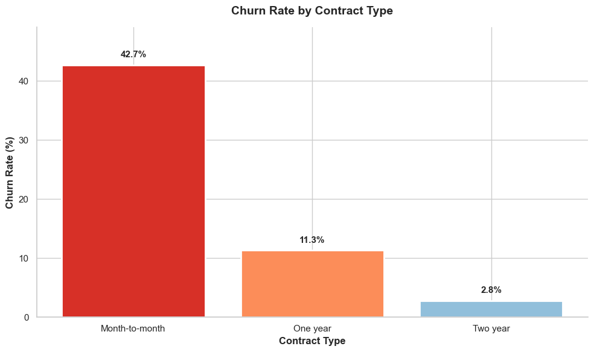

### Chart 2: Monthly Charge Distribution - Churned vs Retained

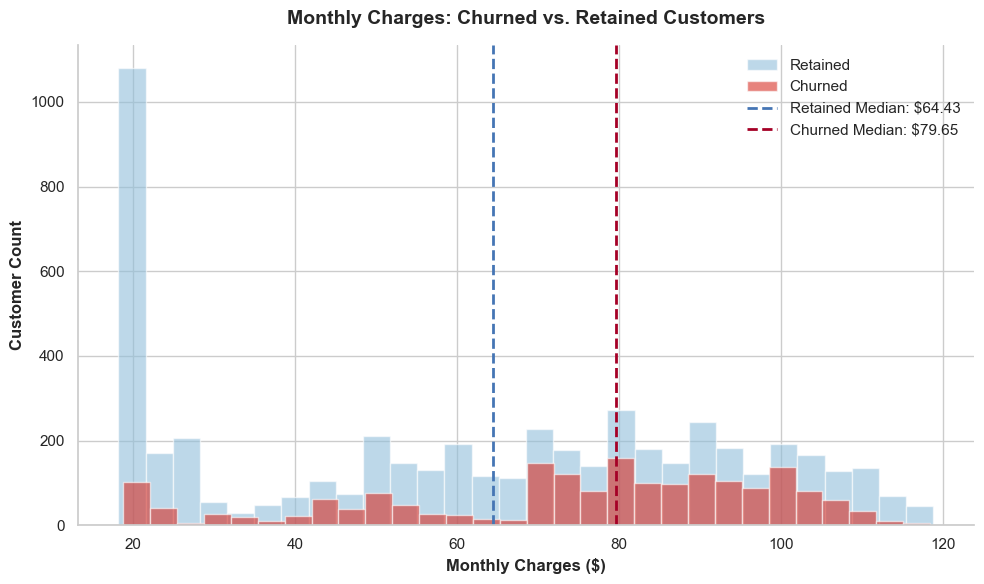

### Chart 3: Monthly Recurring Revenue Impact

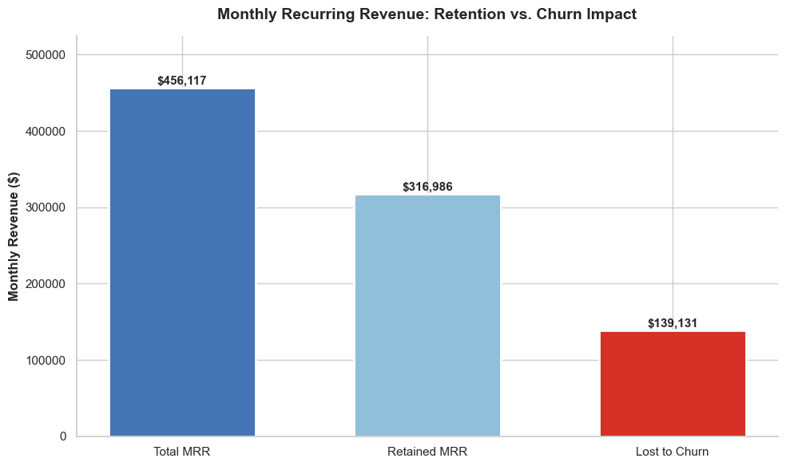

### Chart 4: Risk Tier Validation

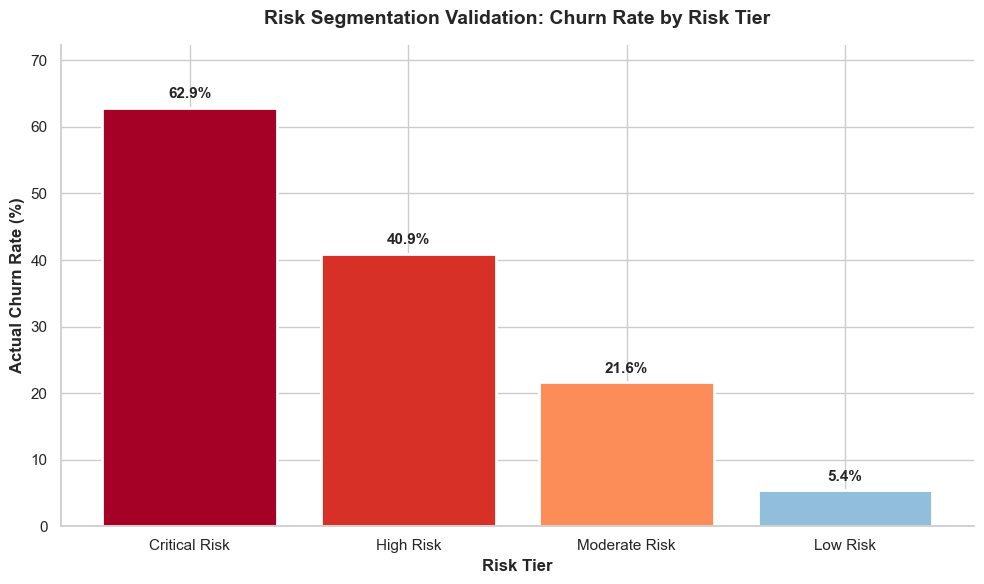

# Telco Customer Churn Analysis

## Internal Analyst Report | Customer Success Team

### Finding 1: Contract Type Is the Dominant Churn Driver

Month-to-month customers churn at **42.7%** — approximately 15x the rate of two-year contract customers (2.8%). This cohort represents the majority of churned revenue despite better pricing opportunities with longer contracts.

**Implication:** A contract conversion campaign targeting month-to-month customers showing early risk signals could have an outsized revenue impact. Even a 10% conversion to one-year contracts could retain an estimated $5,000-7,000 monthly.

### Finding 2: The First 12 Months Are the Danger Zone

Customers in their first year churn at **47.4%**, compared to just **17.1%** for customers beyond 12 months. The 0-12 month cohort represents a critical intervention window where poor onboarding or value misalignment manifest.

**Implication:** Onboarding quality and early engagement are likely causal factors. A 30/60/90-day customer health check program is worth modeling, particularly for month-to-month customers who lack contract friction preventing early exits.

### Finding 3: High Monthly Charges + Low Service Adoption = Churn Risk

Customers paying over $65/month with fewer than 2 add-on services churn at **57.8%** — indicating a severe value perception problem. These customers are paying premium prices but not using enough services to justify the cost in their minds.

**Implication:** These customers are not experiencing sufficient perceived value for their spend. A targeted upsell or bundle offer (particularly TechSupport and OnlineSecurity) could improve both retention and ARPU simultaneously. There's an opportunity to turn a retention problem into a revenue expansion play.

### Risk Segmentation Output

A rules-based risk scoring model flagged **2,598 customers** as High or Critical risk, representing **$100,668/month** in at-risk MRR. This customer list has been exported for prioritization by the retention team. The model correctly identifies customers with **6-12x higher actual churn rates** than the low-risk population.

**Validation Results:**

- Critical Risk tier: 62.9% actual churn rate
- High Risk tier: 40.9% actual churn rate
- Moderate Risk tier: 21.6% actual churn rate
- Low Risk tier: 5.4% actual churn rate

### Recommendations

| Priority | Action | Target Segment | Est. Revenue Impact |
| --- | --- | --- | --- |
| High | Contract conversion offer | M2M customers, Risk Score ≥ 6 | $10-15K/month retained |
| High | Early lifecycle check-in (day 60) | Tenure < 6 months, Critical/High risk | Reduce early churn by est. 15-20% |
| Medium | Bundle promotion with discount | MonthlyCharges > $65, Service_Count < 2 | Dual retention + upsell opportunity |
| Low | Payment method incentive | Electronic check users | Reduces friction churn marginally |

### Limitations & Next Steps

- **No causal data:** We observe correlation, not causation. Support ticket history, NPS scores, and usage logs would strengthen findings and help distinguish between customers who leave due to dissatisfaction vs. life circumstances.
- **Static snapshot:** This is point-in-time data, not a time series. Longitudinal analysis would validate lifecycle findings and help us understand if churn patterns are seasonal or trend-based.
- **Model sophistication:** The current risk scoring is rule-based. A logistic regression or gradient boosting model could potentially improve prediction accuracy, though interpretability would decrease.

### Technical Approach

This analysis used:

- **Pandas** for data manipulation and aggregation
- **Matplotlib/Seaborn** for visualization
- **SQLite** for query validation and stakeholder self-service
- **Sklearn** for predictive modeling benchmarks

The risk segmentation framework is production-ready and can be deployed as a weekly batch scoring process with minimal engineering overhead.